# **Assignment 10**

### **Topic: Using real-world data for hypothesis generation**

**Dataset:** exposome.RData

**1. Examine the different features within the data frames and provide some descriptive measures (for continuous measures: means and ranges, for categorical/binary: frequency counts). Feel free to look at correlations between features, examine missingness, and other exploratory data analyses. You don’t need to do this for all features within the data frames (although you could) but you should document summaries for at least 5 features from exposome and 1 feature from phenotype.**

**ANSWER:**

**Import dataset**

```r
library(tidyverse)
library(caret)
library(glmnet)

# Load data
load("exposome.RData")

# Merge all data frames into a single data frame
studydata = merge(exposome, phenotype, by = "ID") |>
  merge(covariates, by = "ID")

# Remove ID
studydata$ID = NULL

# Keep variables for this analysis
studydata = studydata |>
  select(
    hs_correct_raven,
    h_greenyn300_preg_None,
    h_ndvi100_preg_None,
    hs_greenyn300_h_None,
    hs_ndvi100_h_None,
    h_NO2_Log,
    h_builtdens300_preg_Sqrt,
    e3_bw
  )
```

**Exploratory data analysis**

```r
# Outcome
summary(studydata$hs_correct_raven)
```

```
##    Min. 1st Qu.  Median    Mean 3rd Qu.    Max.
##    9.00   22.00   27.00   26.29   32.00   36.00
```

```r
mean(studydata$hs_correct_raven, na.rm = TRUE)
```

```
## [1] 26.28824
```

```r
range(studydata$hs_correct_raven, na.rm = TRUE)
```

```
## [1]  9 36
```

```r
# Exposome variables: continuous
summary(studydata$h_ndvi100_preg_None)
```

```
##    Min. 1st Qu.  Median    Mean 3rd Qu.    Max.
##  0.1062  0.2488  0.4105  0.3917  0.5158  0.7354
```

```r
mean(studydata$h_ndvi100_preg_None, na.rm = TRUE)
```

```
## [1] 0.3917125
```

```r
range(studydata$h_ndvi100_preg_None, na.rm = TRUE)
```

```
## [1] 0.1061946 0.7354429
```

```r
summary(studydata$hs_ndvi100_h_None)
```

```
##    Min. 1st Qu.  Median    Mean 3rd Qu.    Max.
## 0.09675 0.31847 0.47907 0.45053 0.57471 0.81432
```

```r
mean(studydata$hs_ndvi100_h_None, na.rm = TRUE)
```

```
## [1] 0.4505269
```

```r
range(studydata$hs_ndvi100_h_None, na.rm = TRUE)
```

```
## [1] 0.09675429 0.81432121
```

```r
summary(studydata$h_NO2_Log)
```

```
##    Min. 1st Qu.  Median    Mean 3rd Qu.    Max.
##   1.573   2.979   3.617   3.833   4.576   7.093
```

```r
mean(studydata$h_NO2_Log, na.rm = TRUE)
```

```
## [1] 3.832765
```

```r
range(studydata$h_NO2_Log, na.rm = TRUE)
```

```
## [1] 1.573213 7.092562
```

```r
summary(studydata$h_builtdens300_preg_Sqrt)
```

```
##    Min. 1st Qu.  Median    Mean 3rd Qu.    Max.
##   11.02  340.04  401.49  417.06  502.97  807.57
```

```r
mean(studydata$h_builtdens300_preg_Sqrt, na.rm = TRUE)
```

```
## [1] 417.0643
```

```r
range(studydata$h_builtdens300_preg_Sqrt, na.rm = TRUE)
```

```
## [1]  11.01832 807.56747
```

```r
# Exposome variables: binary
table(studydata$h_greenyn300_preg_None, useNA = "ifany")
```

```
##
##   0   1
## 321 980
```

```r
table(studydata$hs_greenyn300_h_None, useNA = "ifany")
```

```
##
##    0    1
##  274 1027
```

```r
# Missingness count
colSums(is.na(studydata))
```

```
##         hs_correct_raven   h_greenyn300_preg_None      h_ndvi100_preg_None
##                        0                        0                        0
##     hs_greenyn300_h_None        hs_ndvi100_h_None                h_NO2_Log
##                        0                        0                        0
## h_builtdens300_preg_Sqrt                    e3_bw
##                        0                        0
```

```r
# Missingness proportion
colMeans(is.na(studydata))
```

```
##         hs_correct_raven   h_greenyn300_preg_None      h_ndvi100_preg_None
##                        0                        0                        0
##     hs_greenyn300_h_None        hs_ndvi100_h_None                h_NO2_Log
##                        0                        0                        0
## h_builtdens300_preg_Sqrt                    e3_bw
##                        0                        0
```

```r
# Covariate: birth weight
summary(studydata$e3_bw)
```

```
##    Min. 1st Qu.  Median    Mean 3rd Qu.    Max.
##    1100    3080    3398    3389    3720    5260
```

```r
mean(studydata$e3_bw, na.rm = TRUE)
```

```
## [1] 3389.302
```

```r
range(studydata$e3_bw, na.rm = TRUE)
```

```
## [1] 1100 5260
```

```r
# Correlation among numeric variables
numeric_vars = studydata %>% select(where(is.numeric))
cor(numeric_vars)
```

```
##                          hs_correct_raven h_ndvi100_preg_None hs_ndvi100_h_None
## hs_correct_raven               1.00000000           0.1498355         0.1385390
## h_ndvi100_preg_None            0.14983550           1.0000000         0.6761227
## hs_ndvi100_h_None              0.13853901           0.6761227         1.0000000
## h_NO2_Log                     -0.06534646          -0.2568914        -0.4084560
## h_builtdens300_preg_Sqrt       0.01238291          -0.6301842        -0.4886789
## e3_bw                          0.12106298           0.1904669         0.1509159
##                             h_NO2_Log h_builtdens300_preg_Sqrt        e3_bw
## hs_correct_raven         -0.065346463               0.01238291  0.121062978
## h_ndvi100_preg_None      -0.256891431              -0.63018415  0.190466901
## hs_ndvi100_h_None        -0.408456017              -0.48867894  0.150915912
## h_NO2_Log                 1.000000000               0.26468008 -0.007732229
## h_builtdens300_preg_Sqrt  0.264680083               1.00000000 -0.104205194
## e3_bw                    -0.007732229              -0.10420519  1.000000000
```

The outcome variable, `hs_correct_raven`, is continuous. The mean score was 26.29, with a range from 9 to 36, indicating variation in cognitive performance among children.

For the exposome variables, NDVI measures during pregnancy and at home had means of 0.39 and 0.45, respectively, with wide ranges, indicating differences in surrounding vegetation. Air pollution (NO2) also varied across participants, with a mean of 3.83. Built density showed a large range, suggesting differences in urban environments.

For binary variables, most children were exposed to green space within 300 meters during pregnancy (980 vs. 321) and at home (1027 vs. 274).

Birth weight (e3_bw) was examined as a continuous covariate, with a mean of 3,389 grams and a range from 1,100 to 5,260 grams.

Correlations among numeric variables were examined. NDVI measures during pregnancy and at home showed a moderate positive correlation (r ≈ 0.68), indicating they capture similar aspects of vegetation. NDVI was negatively correlated with air pollution (NO2) and built density, suggesting that greener areas tend to have lower pollution and less dense environments.

Lastly, there were no missing values in the selected variables above.

**2. Develop a single research question. It can be a prediction or hypothesis generating research question. It doesn’t need to involve all features but it must involve at least one outcome from phenotype and 5 features from exposome (and covariates if relevant).**

**ANSWER:**

**Outcome variable:** `hs_correct_raven` (Intelligence quotient at 6-11 years old - Total of correct answers at the RAVEN test)

**Features from exposome:**

- `h_greenyn300_preg_None` (Is there a greenspace in a distance of 300m?at pregnancy period)
- `h_ndvi100_preg_None` (Average of NDVI values within a buffer of 100mat pregnancy period)
- `hs_greenyn300_h_None` (Is there a greenspace in a distance of 300m?at home)
- `hs_ndvi100_h_None` (Average of NDVI values within a buffer of 100mat home)
- `h_NO2_Log` (Concentration of indoor NO2)
- `h_builtdens300_preg_Sqrt` (Building density (m2 built/km2) within a buffers of 300mat pregnancy period)

**Research question:** Is cognitive performance, measured by intelligence quotient (`hs_correct_raven`), associated with environmental exposures such as green space, vegetation, air pollution, and built environment?

**3. Implement one algorithm from class that we’ve used previously to address your question. For this assignment, you should partition your data, develop the model in training (including hyperparameter turning and cross-validation) and then get final evaluation metrics in testing data. You can use package defaults for tuning or create your own vectors/grids. This is to keep getting practice with implementing algorithms so do as much as you would like and find useful.**

**ANSWER:**

To address the research question, an elastic net regression model was applied. The data were first partitioned into training and testing sets (70:30). The model was trained using 10-fold cross-validation with hyperparameter tuning. Model performance was then evaluated in the testing set using RMSE and R-squared.

```r
# Partition data
set.seed(123)
train.indices = createDataPartition(y = studydata$hs_correct_raven, p = 0.7, list = FALSE)

train.data = studydata[train.indices, ]
test.data  = studydata[-train.indices, ]

# Train model
set.seed(123)
EN_model = train(
  hs_correct_raven ~
    h_greenyn300_preg_None +
    h_ndvi100_preg_None +
    hs_greenyn300_h_None +
    hs_ndvi100_h_None +
    h_NO2_Log +
    h_builtdens300_preg_Sqrt +
    e3_bw,
  data = train.data,
  preProcess = "scale",
  method = "glmnet",
  trControl = trainControl("cv", number = 10),
  tuneLength = 10
)

# Best tuning parameters
EN_model$bestTune
```

```
##    alpha    lambda
## 46   0.6 0.1779676
```

```r
# Extract coefficients at best lambda
coef_vals = coef(EN_model$finalModel, s = EN_model$bestTune$lambda)

# Convert to data frame and remove intercept
coef_df = as.data.frame(as.matrix(coef_vals))
colnames(coef_df) = "Coefficient"
coef_df$Variable = rownames(coef_df)
coef_df = coef_df[coef_df$Variable != "(Intercept)", ]
coef_df = coef_df[coef_df$Coefficient != 0, ]  # keep only non-zero (selected) terms

# Print coefficients
print(coef_df)
```

```
##                          Coefficient                 Variable
## h_ndvi100_preg_None        1.1481480      h_ndvi100_preg_None
## hs_ndvi100_h_None          0.5086628        hs_ndvi100_h_None
## h_builtdens300_preg_Sqrt   0.9506024 h_builtdens300_preg_Sqrt
## e3_bw                      0.4659210                    e3_bw
```

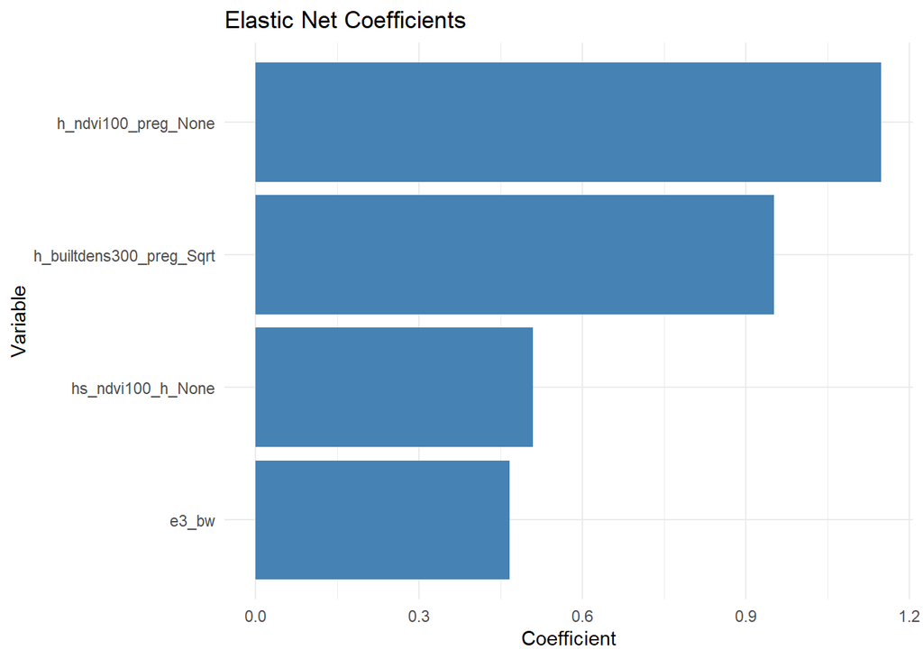

```r
# Plot
library(ggplot2)
ggplot(coef_df, aes(x = reorder(Variable, Coefficient), y = Coefficient)) +
  geom_bar(stat = "identity", fill = "steelblue") +
  coord_flip() +
  labs(title = "Elastic Net Coefficients",
       x = "Variable",
       y = "Coefficient") +
  theme_minimal()
```

```r
# Predict
EN_model.pred = EN_model |> predict(test.data)

# Evaluate
data.frame(
  RMSE = RMSE(EN_model.pred, test.data$hs_correct_raven),
  Rsquare = R2(EN_model.pred, test.data$hs_correct_raven)
)
```

```
##       RMSE    Rsquare
## 1 6.179683 0.03560444
```

**Description:** An elastic net regression model was applied to assess associations between environmental exposures and cognitive performance. The optimal model was selected at α = 0.6 and λ = 0.178. Four predictors with non-zero coefficients were retained: prenatal NDVI (`h_ndvi100_preg_None`), built environment density (`h_builtdens300_preg_Sqrt`), postnatal NDVI (`hs_ndvi100_h_None`), and birth weight (`e3_bw`). Binary green space indicators and NO₂ were reduced to zero.

In the testing set, the model yielded an RMSE of **6.18** and an R-squared of **0.036**, indicating that the selected variables accounted for only 3.56% of the variance in cognitive performance. These findings indicate that the included environmental exposures have limited predictive value for cognitive performance in this sample and should be interpreted cautiously. However, the prominence of NDVI-based vegetation measures as predictors offers a foundation for future hypothesis-driven research on the influence of green space in child cognitive development.

#### **AI tools**

Claude.ai was used in this assignment to assist with debugging R code syntax errors and editing text for clarity and conciseness.